# Why Did President Barack Obama Win Again If His Approval Ratings Were Declining?

# 1. Introduction

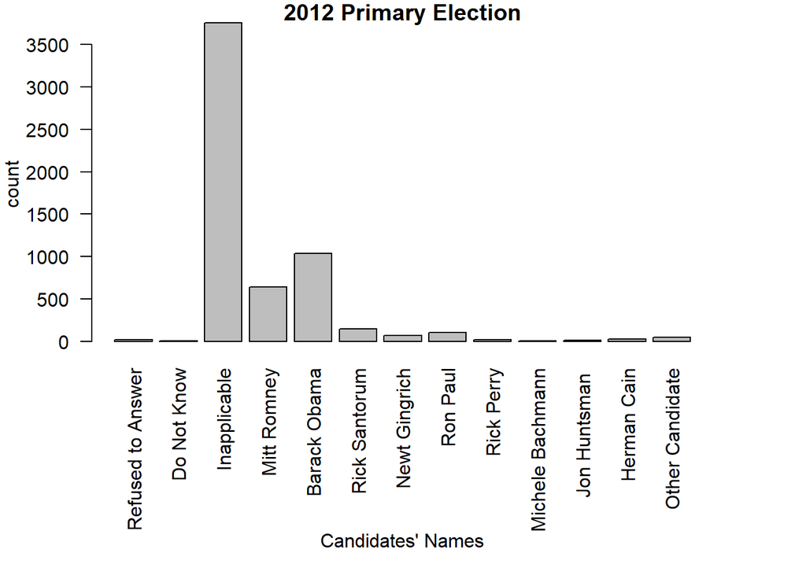

The graph above shows the vote counts of 2012 primary elections and it includes ‘inapplicable’ counts bicide the individual candidates counts.

The 44th President and the First African American President, Barack Obama was in office for two terms. At the end of his first term his approval ratings fell from the high 60% is to about 40%. However, despite his declining approval ratings he managed to get elected for a second term in office. This begs the question, if President Barack Obama’s approval ratings were declining what caused him to win again in 2012?

# 2. About Data

I have used 2012 Time Series Study Survey Data from the ‘American National Election Studies’ (ANES). For the first time ANES used the Internet to conduct it’s survey. The participants that filled out the online survey were selected from the ‘GfK Knowledge Networks’. Thus, the data was compiled from respondents that filled out the online administered survey and compiled from traditional survey method (a person asks the respondents questions). The participants were given money incentives to fill out the pre and post election surveys, amounts ranged from $65 to $125. The pre part of the survey was conducted from September 1st 2012 to November 5th 2012 and the post part of the survey was conducted from November 6th 2012 to January 1st 2013. In this data set there are, 2249, variables in total and, 5914, respondents have filled out this survey (Pre and Post).

# 3. Methodology

During any presidential election there typically three big ticket subjects that the public looks at when selecting a candidate to vote for. The general population looks at what the future president stance is on health care, how they are going to handle economic problems, and how they are going to handle foreign relations with other countries. Hence, to answer the question I posed above, I looked at a variables from the survey that answered these 3 big ticket subjects.

# 4. Analysis

Looking at the first big ticket subject of health care:

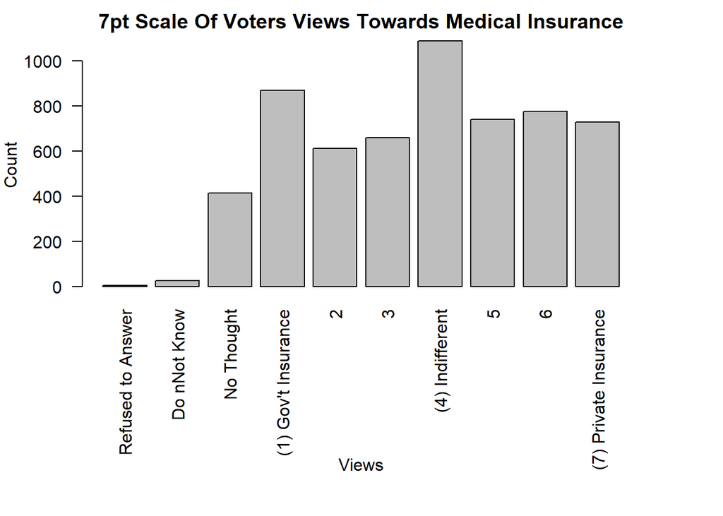

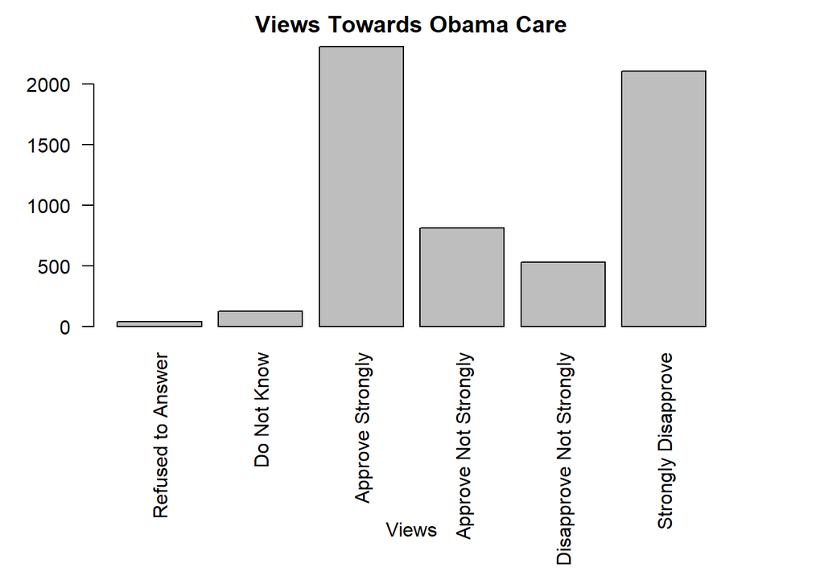

Looking at the ‘7pt Scale Of Voters Views Towards Medical Insurance’ graph, overall voters are spread out on the spectrum of for government insurance plan to private insurance plan. Inface a large number of voters are indifferent towards any specific plan. Furthermore, looking at “Views Towards Obama Care’ graph a significant amount of people are in the catorgires of Approve then Disapprove. Majority of the voters are in favor of Obema Care. Obema care is a”law enacted to ensure that all Americans have access to affordable health insurance (abcnews.com)." It is neither forces individuals to get a private insurance plan no government insurance plan. It is just there to help with the primeum coverage and make health insurance more affordable. Obama’s views of health care align with the voters because his Care Act works with both types of insurance plans making his views favoriable to all.

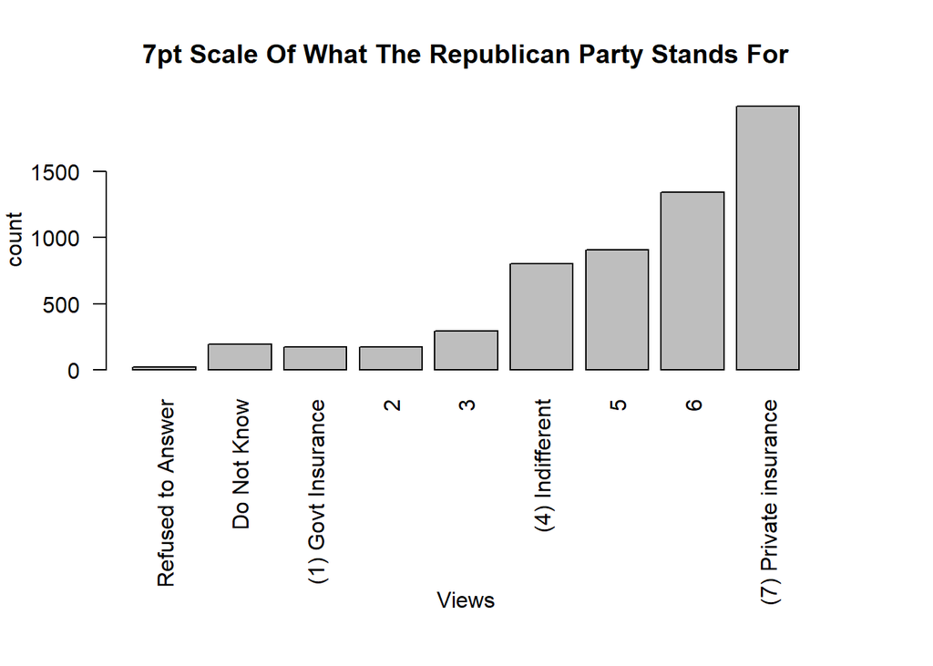

Whereas if you look at ‘7pt Scale Of What The Respondents Think The Republican Party Stands For’ graph, most voters think the republican candidate stanads for private insurance plan. This causes him to loose the votes of those that are in favor of government insurance plan (as you can see in the first graph that is close to a thirs of the respondents).